# 第2回 ベイズ勉強会：階層モデル

Taka-aki Asano

2017/4/21

最初に、必要なパッケージを読み込んでおく。

```r
library("ggplot2")
library("plyr")
```

# ネズミの腫瘍実験

## 階層モデルによる推定

使用するデータはBDAと同じものを用いる。

```r
experiments <- data.frame(y = c(rep(0, 14), rep(1, 8), rep(2, 9), 1, 5, 2, 5, 3,
                                2, 7, 7, 3, 3, 2, 9, 10, rep(4, 7), 10, 4, 4, 4,
                                5, 11, 12, 5, 5, 6, 5, rep(6, 4), 16, 15, 15, 9,
                                4),
                          n = c(rep(20, 7), rep(19, 4), 18, 18, 17, rep(20, 4),
                                19, 19, 18, 18, 25, 24, 23, rep(20, 6), 10, 49,
                                19, 46, 27, 17, 49, 47, 20, 20, 13, 48, 50,
                                rep(20, 7), 48, rep(19, 3), 22, 46, 49, 20, 20,
                                23, 19, 22, rep(20, 3), 52, 47, 46, 24, 14))
```

各個体は腫瘍を患うか否かの二択なので、各実験は二項分布でモデル化できる。したがって、
$$y_j|\theta_j \sim \mathrm{Bin}(n_j, \theta_j)$$
となる。なお、$n_j$は各実験でのサンプルサイズである。また、このモデルを前提にすると、使用するデータの尤度関数は、
$$p(y | \theta, \alpha, \beta) = \prod_{j = 1}^{J} \theta_j^{y_j} (1 - \theta_j)^{n_j - y_j}$$
である。

次に、母数である$\theta$の事前分布は、
$$\theta_j \sim \mathrm{Beta}(\alpha, \beta).$$
とする。

ここで、母数$\theta$の母数$\alpha$と$\beta$が出てくる。この母数の母数のことを、**超母数**と呼ぶ。超母数の事前分布(=**超事前分布**)は(5.9)の式なので、
$$p(\alpha, \beta) \propto (\alpha + \beta)^{-5/2}$$
である。

$\alpha$と$\beta$が決まったときの$\theta$の条件付き確率は、ベータ分布の確率密度関数より、
$$p(\theta | \alpha, \beta) = \prod_{j = 1}^{J} \frac{\Gamma(\alpha + \beta)}{\Gamma(\alpha)\Gamma(\beta)} \theta_j^{\alpha - 1} (1 - \theta_j)^{\beta - 1}$$
となる。なお、$J$は実験回数である。

全母数の同時事後分布は、
$$p(\theta, \alpha, \beta | y) \propto p(\alpha, \beta) p(\theta | \alpha, \beta) p(y | \theta, \alpha, \beta)$$
である。これは、尤度関数・超事前分布・$\theta$の条件付き確率より、
$$p(\theta, \alpha, \beta | y) \propto (\alpha + \beta)^{-5/2} \prod_{j = 1}^{J} \frac{\Gamma(\alpha + \beta)}{\Gamma(\alpha)\Gamma(\beta)} \theta_j^{\alpha - 1} (1 - \theta_j)^{\beta - 1} \prod_{j = 1}^{J} \theta_j^{y_j} (1 - \theta_j)^{n_j - y_j}$$
となる。これが(5.6)の式になる。

$\alpha$と$\beta$が決まったときの$\theta$の条件付き事後確率は、
$$p(\theta | \alpha, \beta, y) = \prod_{j = 1}^{J} \frac{\Gamma(\alpha + \beta + n_j)}{\Gamma(\alpha + y_j)\Gamma(\beta + n_j - y_j)} \theta_j^{\alpha + y_j - 1} (1 - \theta_j)^{\beta + n_j - y_j - 1}$$
である。これは(5.7)の式である。

以上から、超母数の周辺事後分布は、
$$\begin{eqnarray*}
p(\alpha, \beta| y) &=& p(\theta, \alpha, \beta | y) / p(\theta | \alpha, \beta, y) \\
&\propto& (\alpha + \beta)^{-5/2} \prod_{j = 1}^{J} \frac{\Gamma(\alpha + \beta)}{\Gamma(\alpha)\Gamma(\beta)} \frac{\Gamma(\alpha + y_j)\Gamma(\beta + n_j - y_j)}{\Gamma(\alpha + \beta + n_j)}
\end{eqnarray*}$$
になると考えられる。

BDAでは、超母数の事後確率は自然対数化している。加えて、超母数$(\alpha, \beta)$を$(\log(\alpha / \beta), \log(\alpha + \beta))$に変換している。したがって、
$$p(\phi_1, \phi_2) \propto \alpha\beta(\alpha + \beta)^{-5/2}$$
$$\phi_1 = \log(\alpha / \beta)$$
$$\phi_2 = \log(\alpha + \beta)$$
とする。

変換した超母数$(\phi_1, \phi_2)$の周辺事後分布を等高線で描いてみよう。

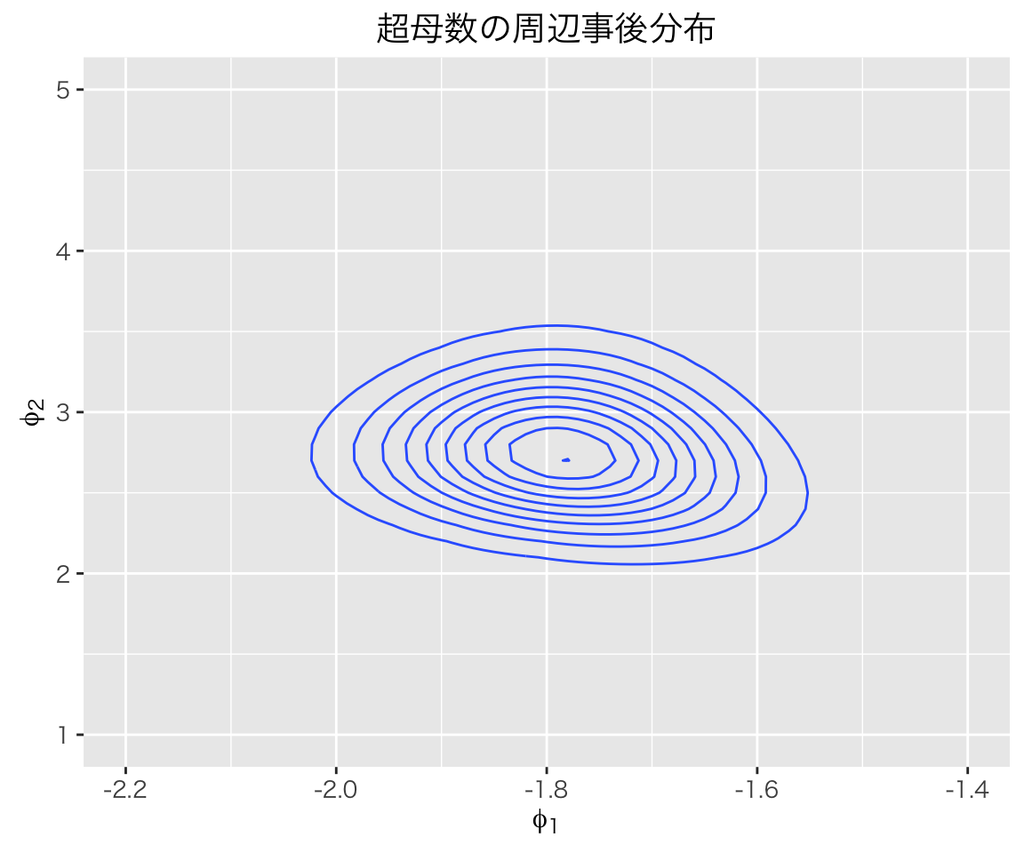

```r
# 格子の準備
phi1 <- seq(-2.3, -1.3, by = 0.01)
phi2 <- seq(1, 4.6, by = 0.1)
Grid <- expand.grid(phi1, phi2)
names(Grid) <- c("phi1", "phi2")

# Φを元の超母数に戻す関数を準備
## α
re_alpha <- function(phi1, phi2) {
  alpha <- exp(phi1 + phi2) / (1 + exp(phi1))
  return(alpha)
}
## β
re_beta <- function(phi1, phi2) {
  beta <- exp(phi2) / (1 + exp(phi1))
  return(beta)
}

# 超母数の周辺事後確率を計算する関数も準備
post_hyper <- function(alpha, beta, y, n) {
  s <- log((gamma(alpha + beta) / (gamma(alpha)*gamma(beta))) *
             (gamma(alpha + y)*gamma(beta + n - y) / gamma(alpha + beta + n)))
  hyper <- (-5/2) * log(alpha + beta) + log(alpha) + log(beta) + sum(s)
  return(hyper)
}

# 周辺事後確率を計算
Grid$post <- rep(NA, nrow(Grid))
for (i in 1:nrow(Grid)) {
  alpha <- re_alpha(Grid$phi1[i], Grid$phi2[i])
  beta <- re_beta(Grid$phi1[i], Grid$phi2[i])
  Grid$post[i] <- post_hyper(alpha, beta, experiments$y, experiments$n)
}
Grid$post <- with(Grid, exp(post - max(post)))

# 等高線をプロット
plot_post <- ggplot(Grid, aes(x = phi1, y = phi2, z = post)) +
  geom_contour() +
  xlim(-2.2, -1.4) + ylim(1, 5) +
  labs(x = expression(phi[1]), y = expression(phi[2]),
       title = "超母数の周辺事後分布")
print(plot_post)
```

これは、Figure 5.3(a)を再現したものである。

続いて、周辺事後分布を元に、$\phi_1$と$\phi_2$の組み合わせを1000個サンプリングする。

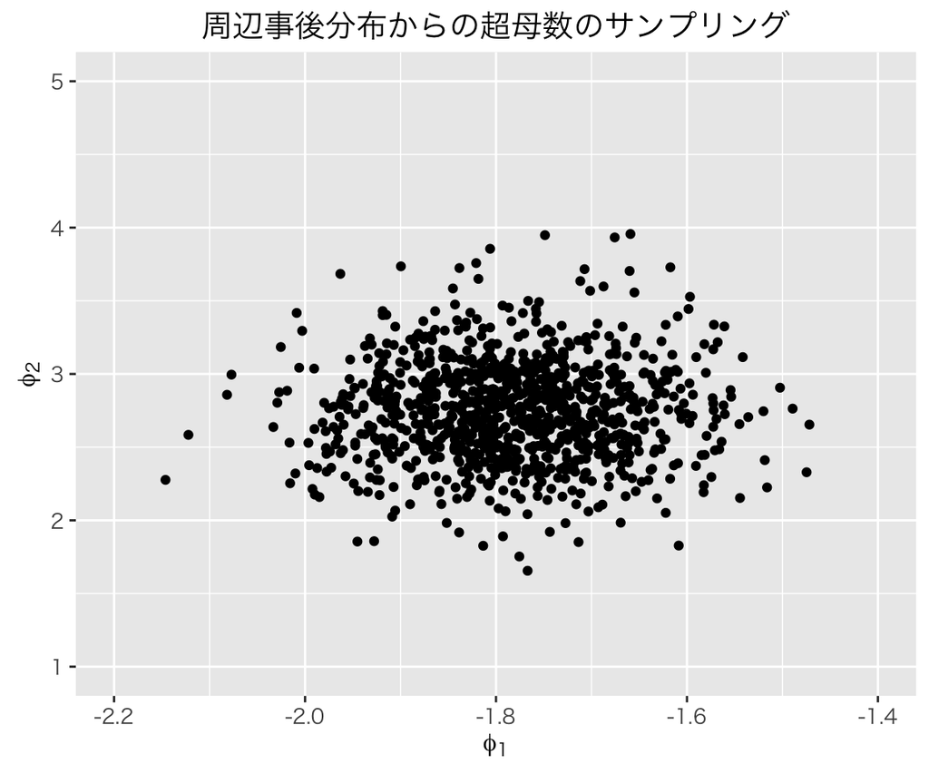

```r
# サンプリング結果の保存先
Sampling <- data.frame(phi1 = rep(NA, 1000), phi2 = rep(NA, 1000))

# それぞれの事後確率を周辺化して求める
mg_phi1 <- ddply(Grid, .(phi1), summarize, density = sum(post))
mg_phi2 <- ddply(Grid, .(phi2), summarize, density = sum(post))

# サンプリング
for (i in 1:1000) {
  # Φ1のサンプリング
  Sampling$phi1[i] <- sample(mg_phi1$phi1, size = 1, prob = mg_phi1$density) +
    runif(1, min = -0.005, max = 0.005)
  # Φ2のサンプリング
  Sampling$phi2[i] <- sample(mg_phi2$phi2, size = 1, prob = mg_phi2$density) +
    runif(1, min = -0.05, max = 0.05)
}

# サンプリング結果を散布図でプロット
plot_sampling <- ggplot(Sampling, aes(phi1, phi2)) +
  geom_point() +
  xlim(-2.2, -1.4) + ylim(1, 5) +
  labs(x = expression(phi[1]), y = expression(phi[2]),
       title = "周辺事後分布からの超母数のサンプリング")
print(plot_sampling)
```

これは、Figure 5.3(b)を再現したものになる。

サンプリングされた1000組の$\phi_1$と$\phi_2$から、$\alpha$と$\beta$も1000組作ることが出来る。

```r
Sampling$alpha <- re_alpha(Sampling$phi1, Sampling$phi2)
Sampling$beta <- re_beta(Sampling$phi1, Sampling$phi2)
```

この$\alpha$と$\beta$を使うと、$\theta$の条件付き事後分布は、
$$\theta_j | \alpha, \beta, y \sim \mathrm{Beta} (\alpha + y_j, \beta + n_j - y_j)$$
となる。

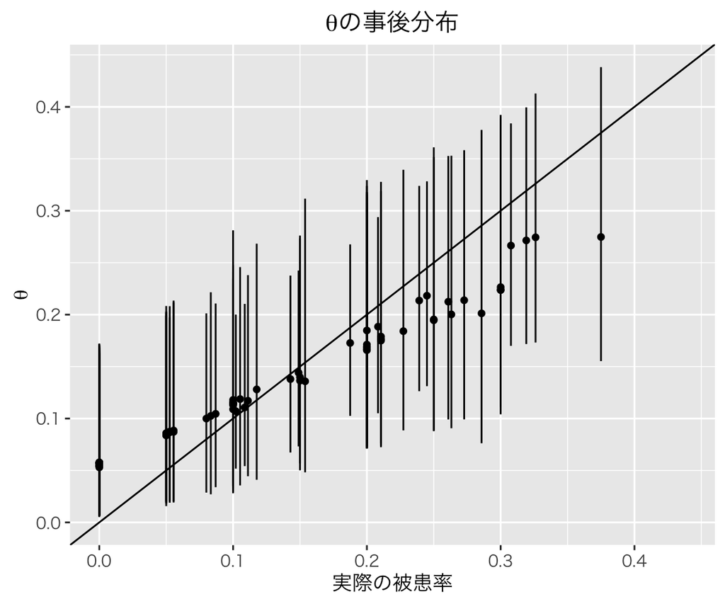

```r
# 各実験でのθの値をサンプリング
post_theta <- matrix(NA, ncol = nrow(experiments), nrow = 1000)
for (i in 1:nrow(experiments)) {
  post_theta[,i] <- rbeta(1000, Sampling$alpha + experiments$y[i],
                          Sampling$beta + experiments$n[i] - experiments$y[i])
}

# 各実験でのθの値の分布から以下を計算
## 中央値
median <- apply(post_theta, 2, median)
## 事後分布区間の上限（BDAに倣って95%区間を考える）
upper <- apply(post_theta, 2, function(x) quantile(x, .975))
## 事後分布区間の下限
lower <- apply(post_theta, 2, function(x) quantile(x, .025))

# データフレームにまとめる
post_theta <- data.frame(rate = experiments$y / experiments$n,
                         median = median, upper = upper, lower = lower)

# 図示
plot_theta <- ggplot(post_theta, aes(rate, median)) +
  geom_point() +
  geom_linerange(aes(ymin = lower, ymax = upper)) +
  xlim(0, max(post_theta$upper)) + ylim(0, max(post_theta$upper)) +
  geom_abline(intercept = 0, slope = 1) +
  labs(x = "実際の被患率", y = expression(theta),
       title = expression(paste(theta, "の事後分布")))
print(plot_theta)
```

これがFigure 5.4になる。

## 実験ごとに別々に推定

階層モデルの意味を理解するために、今度は実験ごとに別々に$\theta_j$を推定してみよう。この問題は以下のようにモデル化できる。
$$y_j \sim \mathrm{Bin}(n_j, \theta_j)$$
$$p(y_j|\theta_j) = \theta_j^{y_j} (1 - \theta_j)^{n_j - y_j}$$
$\theta_j$の事前分布は、無情報であることから、
$$\theta_j \sim \mathrm{Beta}(1, 1)$$
とする。したがって、事後分布は、
$$\theta_j | y_j \sim \mbox{Beta}(1+y_j, 1+n_j-y_j)$$
となる。

実験ごとに、事後分布から$\theta$をサンプリングしてみよう。

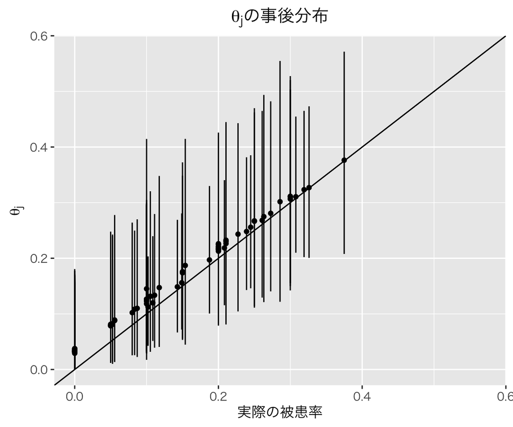

```r
# 計算結果の保存先
m <- nrow(experiments) ## 実験の回数
post_theta <- matrix(rep(NA, 1000*m), nrow = 1000, byrow = FALSE)

# 事後分布を基に、θを1000回サンプリング（実験ごとに同じ作業を繰り返す）
for (i in 1:m) {
  y <- experiments$y[i]
  n <- experiments$n[i]
  alpha <- 1 + y
  beta <- 1 + n - y
  post_theta[,i] <- rbeta(1000, shape1 = alpha, shape2 = beta)
}

# それぞれのサンプリング結果から以下を計算
## 中央値
median <- apply(post_theta, 2, median)
## 事後分布区間の上限（先ほど同様に95%区間を考える）
upper <- apply(post_theta, 2, function(x) quantile(x, .975))
## 事後分布区間の下限
lower <- apply(post_theta, 2, function(x) quantile(x, .025))

# データフレームにまとめる
post_theta <- data.frame(rate = experiments$y / experiments$n,
                         median = median, upper = upper, lower = lower)

# 図示
plot_theta <- ggplot(post_theta, aes(rate, median)) +
  geom_point() +
  geom_linerange(aes(ymin = lower, ymax = upper)) +
  xlim(0, max(post_theta$upper)) + ylim(0, max(post_theta$upper)) +
  geom_abline(intercept = 0, slope = 1) +
  labs(x = "実際の被患率", y = expression(theta[j]),
       title = expression(paste(theta[j], "の事後分布")))
print(plot_theta)
```

推定を実験ごとに行っていることから、事後分布の中央値は、階層モデルよりも実際の悲観率に近い。

## 母数を共通と捉えて推定

今度は、全ての実験において、$\theta$は共通していたと仮定して推定してみる。

二項分布でモデル化するため、
$$y_j \sim \mathrm{Bin}(n_j, \theta)$$
$$p(y_j|\theta) = \theta^{y_j} (1 - \theta)^{n_j - y_j}$$
となる。$\theta$が全ての実験で共通であることから、
$$p(y|\theta) = \prod_{j = 1}^{J}p(y_j|\theta) = \theta^{y} (1 - \theta)^{n - y}$$
となる。また、$\theta_j$の事前分布が無情報であることから、
$$\theta \sim \mathrm{Beta}(1, 1)$$
である。以上から事後分布は、
$$\theta | y \sim \mbox{Beta}(1+y, 1+n-y)$$
となる。

```r
# 事後分布を基に、θを1000回サンプリング
y <- sum(experiments$y)
n <- sum(experiments$n)
alpha <- 1 + y
beta <- 1 + n - y
post_theta <- rbeta(1000, shape1 = alpha, shape2 = beta)

# サンプリング結果の分位数
quantile(post_theta, c(.025, .25, .5, .75, .975))
```

```
##      2.5%       25%       50%       75%     97.5%
## 0.1382743 0.1478634 0.1536142 0.1595724 0.1715420
```

```r
# サンプリングされたθの最大値と最小値はいくらか？
max(post_theta)
```

```
## [1] 0.1794763
```

```r
min(post_theta)
```

```
## [1] 0.1216401
```

```r
# 実際の被患率の最大値と最小値はいくらか？
max(experiments$y / experiments$n)
```

```
## [1] 0.375
```

```r
min(experiments$y / experiments$n)
```

```
## [1] 0
```

全ての実験をまとめて推定すると、実験ごとのばらつきを説明できていないことが分かる。